# Mendelian Randomization Analysis: AUDIT and Alzheimer's Disease

By Dr. Shea Andrews, generated on 2018-08-24

```
## [1] FALSE
```

## Data sources

*AUDIT* [Sanchez-Roige et al BioRxiv 2018](https://www.biorxiv.org/content/early/2018/08/02/275917): A GWAS of the Alcohol Use Disorder Identification Tes (AUDIT) was conducted in the British white individules in the UK Biobank. The GWAS meta-analysis with 23andMe, identified 10 genome-wide significant loci with SNP-heritability of 12%.

*Late Onset Alzheimer’s disease* (LOAD, Lambert et al 2013): The International Genomics of Alzheimer’s Project (IGAP) is a meta-analysis of 4 previously published GWAS datasets: the European Alzheimer’s Disease Imitative (EADI), the Alzheimer Disease Genetics Consortium (ADGC), Cohorts for Heart and Aging Research in Genomic Epidemiology (CHARGE), and Genetic and Environmental Risk in AD (GERAD) and includes a sample of 17,008 LOAD cases and 37,154 cognitively normal elder controls. Participants in IGAP were of European ancestry, the average age was 71 and 58.4% of participants were women.

*Alzheimer’s Age of Onset Surivial* (AAOS, Huang et al 2017): A GWAS of age of onset in LOAD was conducted in 14,406 AD case samples and 25,849 control samples from the IGAP using Cox proportional hazard regressions. Participants were of European ancestry, in cases the the average AAO was 74.8 and 61.7% were women, in controls the average AAE was 79.0 and 59.6% were women.

*CSF Ab42, tau & ptau* (AB42, ptau, tau, Deming et al 2017): A GWAS of CSF AB42, ptau and tau levels (pg/mL) was conducted in 3,146 participants. Participants were of Eurpean ancestry.

## Instrumental Vaibles

**LD Clumping:** For standard two sample MR it is important to ensure that the instruments for the exposure are independent. LD clumping can be performed using the data_clump function from the TwoSampleMR package, which uses EUR samples from the 1000 genomes project to estimate LD between SNPs and amonst SNPs that have and LD above a given threshold, only the SNP with the lowest p-value will be retained.

**Proxy SNPs:** SNPs associated with AUDIT were extracted from the GWAS of LOAD, AAOS, AB42, ptau and tau. Where SNPs were not available in the outcome GWAS, the EUR thousand genomes was queried to identified potential proxy SNPs that are in linkage disequilibrium (r2 > 0.8) of the missing SNP.

### AUDIT

AUDIT: 4995 SNPs (Table 1) were assoicated with were associated with AUDIT at p < 5e-6. After LD clumping, 4920 of 4995 SNPs were removed.

**Table 1:** Independent SNPS associated with AUDIT

| SNP | CHR | POS | Effect_allele | Non_Effect_allele | EAF | Beta | SE | P | N | r2 |
| --- | --- | --- | --- | --- | --- | --- | --- | --- | --- | --- |
| rs10153775 | 2 | 78613996 | A | C | 0.672144 | 0.0061407 | 0.0012930 | 2.044561e-06 | 120510 | 1.6619242284802696e-5 |
| rs1042725 | 12 | 66358347 | T | C | 0.512304 | -0.0055363 | 0.0011984 | 3.845032e-06 | 121604 | 1.531602854807698e-5 |
| rs10923030 | 1 | 88617883 | T | C | 0.228734 | -0.0070126 | 0.0014204 | 7.935970e-07 | 121061 | 1.7350941351481403e-5 |
| rs11119365 | 1 | NA | C | T | NA | -0.0057946 | 0.0012330 | 2.611560e-06 | 113615 | NA |
| rs114658808 | 2 | 119423996 | A | G | 0.0317986 | 0.0212870 | 0.0039239 | 5.806307e-08 | 120734 | 2.790182573573998e-5 |
| rs116203444 | 4 | 100068114 | C | T | 0.025038500000000002 | -0.0367080 | 0.0042830 | 1.042317e-17 | 118560 | 6.578808058726524e-5 |
| rs116258323 | 1 | 214449747 | T | C | 0.0583154 | 0.0124520 | 0.0025917 | 1.552745e-06 | 119452 | 1.7029305896495362e-5 |
| rs11677810 | 2 | 68066201 | A | C | 0.230859 | 0.0068161 | 0.0014150 | 1.458478e-06 | 116771 | 1.6498888028277242e-5 |
| rs11718871 | 3 | 71607159 | C | G | 0.403342 | 0.0059709 | 0.0012113 | 8.264184e-07 | 121139 | 1.7159653206336087e-5 |
| rs11779830 | 8 | 126796400 | C | T | 0.332615 | -0.0058153 | 0.0012571 | 3.734221e-06 | 119250 | 1.5013865323516971e-5 |

[output cut: 65 more lines]

### LOAD

**Table 2:** SNPS associated with AUDIT avalible in LOAD GWAS

| SNP | CHR | POS | Effect_allele | Non_Effect_allele | EAF | Beta | SE | P | r2 | N |
| --- | --- | --- | --- | --- | --- | --- | --- | --- | --- | --- |
| rs12033923 | 1 | 77896355 | C | T | 0.9377 | 0.0422 | 0.0350 | 2.268e-01 | 2.080688e-04 | 54162 |
| rs10923030 | 1 | 88617883 | T | C | 0.2227 | 0.0012 | 0.0196 | 9.508e-01 | 4.985416e-07 | 54162 |
| rs11809772 | 1 | 181625486 | C | A | 0.8666 | -0.0468 | 0.0245 | 5.575e-02 | 5.064029e-04 | 54162 |
| rs12145483 | 1 | 208973877 | C | T | 0.8630 | -0.0252 | 0.0228 | 2.687e-01 | 1.501628e-04 | 54162 |
| rs11119365 | 1 | 210092916 | C | T | 0.8570 | 0.1235 | 0.0775 | 1.113e-01 | 3.738357e-03 | 54162 |
| rs116258323 | 1 | 214449747 | T | C | 0.0565 | -0.0054 | 0.0354 | 8.786e-01 | 3.108908e-06 | 54162 |
| rs370025 | 2 | 13418275 | T | C | 0.0579 | -0.0078 | 0.0339 | 8.171e-01 | 6.637351e-06 | 54162 |
| rs4832509 | 2 | 18059381 | A | G | 0.1326 | 0.0290 | 0.0227 | 2.015e-01 | 1.934590e-04 | 54162 |
| rs1260326 | 2 | 27730940 | T | C | 0.4232 | -0.0008 | 0.0161 | 9.608e-01 | 3.124503e-07 | 54162 |
| rs13415134 | 2 | 44178778 | C | G | 0.4981 | 0.0133 | 0.0154 | 3.876e-01 | 8.844372e-05 | 54162 |

[output cut: 63 more lines]

### AAOS

**Table 3:** SNPS associated with available in AAOS GWAS

| SNP | CHR | POS | Effect_allele | Non_Effect_allele | EAF | Beta | SE | P | r2 | N |
| --- | --- | --- | --- | --- | --- | --- | --- | --- | --- | --- |
| rs12033923 | 1 | 77896355 | T | C | 0.9377 | -0.0149 | 0.0252 | 0.5553000 | 2.593908e-05 | 40255 |
| rs10923030 | 1 | 88617883 | T | C | 0.2227 | -0.0200 | 0.0149 | 0.1794000 | 1.384838e-04 | 40255 |
| rs11809772 | 1 | 181625486 | A | C | 0.8666 | 0.0263 | 0.0200 | 0.1874000 | 1.599249e-04 | 40255 |
| rs12145483 | 1 | 208973877 | T | C | 0.8630 | 0.0082 | 0.0179 | 0.6474000 | 1.589970e-05 | 40255 |
| rs11119365 | 1 | 210092916 | T | C | 0.8570 | -0.0206 | 0.0464 | 0.6573000 | 1.040115e-04 | 40255 |
| rs116258323 | 1 | 214449747 | T | C | 0.0565 | -0.0174 | 0.0297 | 0.5576000 | 3.227891e-05 | 40255 |
| rs370025 | 2 | 13418275 | T | C | 0.0579 | 0.0395 | 0.0261 | 0.1306000 | 1.702158e-04 | 40255 |
| rs4832509 | 2 | 18059381 | A | G | 0.1326 | 0.0348 | 0.0180 | 0.0523800 | 2.785810e-04 | 40255 |
| rs1260326 | 2 | 27730940 | T | C | 0.4232 | -0.0007 | 0.0123 | 0.9537000 | 2.392197e-07 | 40255 |
| rs13415134 | 2 | 44178778 | C | G | 0.4981 | 0.0063 | 0.0187 | 0.7357000 | 1.984471e-05 | 40255 |

[output cut: 64 more lines]

### AB42

**Table 4:** SNPS associated with AUDIT avalible in ab42 GWAS

| SNP | CHR | POS | Effect_allele | Non_Effect_allele | EAF | Beta | SE | P | r2 | N |
| --- | --- | --- | --- | --- | --- | --- | --- | --- | --- | --- |
| rs12033923 | 1 | 77896355 | C | T | 0.0675701 | 0.0192300 | 0.008695 | 0.0270400 | 4.659715e-05 | 2733 |
| rs10923030 | 1 | 88617883 | T | C | 0.2287340 | -0.0041760 | 0.004922 | 0.3963000 | 6.152985e-06 | 3107 |
| rs11809772 | 1 | 181625486 | C | A | 0.8596000 | -0.0438000 | 0.023400 | 0.0606500 | 4.630648e-04 | 54162 |
| rs12145483 | 1 | 208973877 | C | T | 0.1226520 | 0.0040900 | 0.005953 | 0.4922000 | 3.600171e-06 | 3087 |
| rs11119365 | 1 | 210092916 | C | T | 0.8802000 | 0.1348000 | 0.077400 | 0.0815600 | 3.832198e-03 | 54162 |
| rs116258323 | 1 | 214449747 | T | C | 0.0583154 | 0.0010200 | 0.009796 | 0.9171000 | 1.142665e-07 | 3008 |
| rs370025 | 2 | 13418275 | T | C | 0.0598553 | -0.0076490 | 0.008741 | 0.3816000 | 6.584710e-06 | 3092 |
| rs4832509 | 2 | 18059381 | A | G | 0.1317680 | 0.0000903 | 0.006118 | 0.9882000 | 1.865740e-09 | 3065 |
| rs1260326 | 2 | 27730940 | T | C | 0.4048200 | 0.0022120 | 0.004110 | 0.5904000 | 2.357819e-06 | 3115 |
| rs13415134 | 2 | 44178778 | C | G | 0.4665540 | -0.0040240 | 0.004091 | 0.3254000 | 8.060061e-06 | 3059 |

[output cut: 63 more lines]

### Ptau

**Table 5:** SNPS associated with AUDIT avalible in Ptau GWAS

| SNP | CHR | POS | Effect_allele | Non_Effect_allele | EAF | Beta | SE | P | r2 | N |
| --- | --- | --- | --- | --- | --- | --- | --- | --- | --- | --- |
| rs12033923 | 1 | 77896355 | C | T | 0.0675701 | -0.0189900 | 0.011920 | 0.1111000 | 4.544129e-05 | 2451 |
| rs10923030 | 1 | 88617883 | T | C | 0.2287340 | 0.0096400 | 0.006412 | 0.1328000 | 3.278831e-05 | 2825 |
| rs11809772 | 1 | 181625486 | C | A | 0.8596000 | -0.0438000 | 0.023400 | 0.0606500 | 4.630648e-04 | 54162 |
| rs12145483 | 1 | 208973877 | C | T | 0.1226520 | 0.0070040 | 0.007909 | 0.3759000 | 1.055769e-05 | 2805 |
| rs11119365 | 1 | 210092916 | C | T | 0.8802000 | 0.1348000 | 0.077400 | 0.0815600 | 3.832198e-03 | 54162 |
| rs116258323 | 1 | 214449747 | T | C | 0.0583154 | -0.0100800 | 0.012780 | 0.4305000 | 1.115937e-05 | 2737 |
| rs370025 | 2 | 13418275 | T | C | 0.0598553 | 0.0018220 | 0.011550 | 0.8746000 | 3.736148e-07 | 2812 |
| rs4832509 | 2 | 18059381 | A | G | 0.1317680 | -0.0220800 | 0.008053 | 0.0061380 | 1.115511e-04 | 2789 |
| rs1260326 | 2 | 27730940 | T | C | 0.4048200 | -0.0051210 | 0.005377 | 0.3410000 | 1.263717e-05 | 2833 |
| rs13415134 | 2 | 44178778 | C | G | 0.4665540 | -0.0021270 | 0.005363 | 0.6917000 | 2.251943e-06 | 2783 |

[output cut: 63 more lines]

### Tau

**Table 6:** SNPS associated with AUDIT avalible in tau GWAS

| SNP | CHR | POS | Effect_allele | Non_Effect_allele | EAF | Beta | SE | P | r2 | N |
| --- | --- | --- | --- | --- | --- | --- | --- | --- | --- | --- |
| rs12033923 | 1 | 77896355 | C | T | 0.0675701 | -2.030e-02 | 0.012560 | 0.1063000 | 5.192695e-05 | 2728 |
| rs10923030 | 1 | 88617883 | T | C | 0.2287340 | 1.710e-02 | 0.006838 | 0.0124700 | 1.031709e-04 | 3100 |
| rs11809772 | 1 | 181625486 | C | A | 0.8596000 | -4.380e-02 | 0.023400 | 0.0606500 | 4.630648e-04 | 54162 |
| rs12145483 | 1 | 208973877 | C | T | 0.1226520 | 4.303e-03 | 0.008286 | 0.6035000 | 3.984916e-06 | 3080 |
| rs11119365 | 1 | 210092916 | C | T | 0.8802000 | 1.348e-01 | 0.077400 | 0.0815600 | 3.832198e-03 | 54162 |
| rs116258323 | 1 | 214449747 | T | C | 0.0583154 | -5.773e-03 | 0.013660 | 0.6725000 | 3.660343e-06 | 3000 |
| rs370025 | 2 | 13418275 | T | C | 0.0598553 | -6.890e-03 | 0.012300 | 0.5753000 | 5.342761e-06 | 3084 |
| rs4832509 | 2 | 18059381 | A | G | 0.1317680 | -8.394e-03 | 0.008547 | 0.3261000 | 1.612181e-05 | 3059 |
| rs1260326 | 2 | 27730940 | T | C | 0.4048200 | -2.061e-03 | 0.005737 | 0.7194000 | 2.046898e-06 | 3108 |
| rs13415134 | 2 | 44178778 | C | G | 0.4665540 | -1.889e-03 | 0.005715 | 0.7410000 | 1.776177e-06 | 3053 |

[output cut: 63 more lines]

## Data harmonization

Harmonize the exposure and outcome datasets so that the effect of a SNP on the exposure and the effect of that SNP on the outcome correspond to the same allele. The harmonise_data function from the TwoSampleMR package can be used to perform the harmonization step, by default it try’s to infer the forward strand alleles using allele frequency information. EAF were not availbe in the IGAP summary statisitics, as such the allele frequencies reported in the AAOS anaylsis were used.

### AUDIT ~ LOAD

**Table 7:** Harmonized AUDIT and LOAD datasets

| SNP | effect_allele.exposure | other_allele.exposure | effect_allele.outcome | other_allele.outcome | beta.exposure | beta.outcome | eaf.exposure | eaf.outcome | se.outcome | pval.outcome | se.exposure | pval.exposure |
| --- | --- | --- | --- | --- | --- | --- | --- | --- | --- | --- | --- | --- |
| rs10153775 | A | C | A | C | 0.0061407 | -0.0023 | 0.6721440 | 0.3275 | 0.0166 | 8.924e-01 | 0.0012930 | 2.044561e-06 |
| rs1042725 | T | C | T | C | -0.0055363 | 0.0165 | 0.5123040 | 0.4907 | 0.0156 | 2.914e-01 | 0.0011984 | 3.845032e-06 |
| rs10923030 | T | C | T | C | -0.0070126 | 0.0012 | 0.2287340 | 0.2227 | 0.0196 | 9.508e-01 | 0.0014204 | 7.935970e-07 |
| rs11119365 | C | T | C | T | -0.0057946 | 0.1235 | NA | 0.8570 | 0.0775 | 1.113e-01 | 0.0012330 | 2.611560e-06 |
| rs116258323 | T | C | T | C | 0.0124520 | -0.0054 | 0.0583154 | 0.0565 | 0.0354 | 8.786e-01 | 0.0025917 | 1.552745e-06 |
| rs11677810 | A | C | A | C | 0.0068161 | 0.0298 | 0.2308590 | 0.2298 | 0.0200 | 1.358e-01 | 0.0014150 | 1.458478e-06 |
| rs11718871 | C | G | C | G | 0.0059709 | -0.0048 | 0.4033420 | 0.4228 | 0.0159 | 7.639e-01 | 0.0012113 | 8.264184e-07 |
| rs11779830 | C | T | C | T | -0.0058153 | 0.0231 | 0.3326150 | 0.3457 | 0.0165 | 1.603e-01 | 0.0012571 | 3.734221e-06 |
| rs117893703 | T | C | T | C | 0.0185660 | -0.0214 | 0.0203727 | 0.0167 | 0.0923 | 8.164e-01 | 0.0040042 | 3.542420e-06 |
| rs11809772 | C | A | C | A | -0.0087275 | -0.0468 | 0.1358640 | 0.8666 | 0.0245 | 5.575e-02 | 0.0017526 | 6.379696e-07 |

[output cut: 55 more lines]

### AUDIT ~ AAOS

**Table 8:** Harmonized AUDIT and AAOS datasets

| SNP | effect_allele.exposure | other_allele.exposure | effect_allele.outcome | other_allele.outcome | beta.exposure | beta.outcome | eaf.exposure | eaf.outcome | se.outcome | pval.outcome | se.exposure | pval.exposure |
| --- | --- | --- | --- | --- | --- | --- | --- | --- | --- | --- | --- | --- |
| rs10153775 | A | C | A | C | 0.0061407 | -0.0007 | 0.6721440 | 0.6725 | 0.0130 | 0.9571000 | 0.0012930 | 2.044561e-06 |
| rs1042725 | T | C | T | C | -0.0055363 | 0.0118 | 0.5123040 | 0.5093 | 0.0134 | 0.3767000 | 0.0011984 | 3.845032e-06 |
| rs10923030 | T | C | T | C | -0.0070126 | -0.0200 | 0.2287340 | 0.2227 | 0.0149 | 0.1794000 | 0.0014204 | 7.935970e-07 |
| rs11119365 | C | T | C | T | -0.0057946 | 0.0206 | NA | 0.1430 | 0.0464 | 0.6573000 | 0.0012330 | 2.611560e-06 |
| rs114658808 | A | G | A | G | 0.0212870 | -0.1125 | 0.0317986 | 0.0267 | 0.0438 | 0.0102600 | 0.0039239 | 5.806307e-08 |
| rs116203444 | C | T | C | T | -0.0367080 | 0.1461 | 0.0250385 | 0.0363 | 0.0766 | 0.0564700 | 0.0042830 | 1.042317e-17 |
| rs116258323 | T | C | T | C | 0.0124520 | -0.0174 | 0.0583154 | 0.0565 | 0.0297 | 0.5576000 | 0.0025917 | 1.552745e-06 |
| rs11677810 | A | C | A | C | 0.0068161 | -0.0262 | 0.2308590 | 0.2298 | 0.0324 | 0.4190000 | 0.0014150 | 1.458478e-06 |
| rs11718871 | C | G | C | G | 0.0059709 | 0.0028 | 0.4033420 | 0.4228 | 0.0195 | 0.8868000 | 0.0012113 | 8.264184e-07 |
| rs11779830 | C | T | C | T | -0.0058153 | -0.0055 | 0.3326150 | 0.3290 | 0.0278 | 0.8434000 | 0.0012571 | 3.734221e-06 |

[output cut: 62 more lines]

### AUDIT ~ AB42

**Table 9:** Harmonized AUDIT and AB42 datasets

| SNP | effect_allele.exposure | other_allele.exposure | effect_allele.outcome | other_allele.outcome | beta.exposure | beta.outcome | eaf.exposure | eaf.outcome | se.outcome | pval.outcome | se.exposure | pval.exposure |
| --- | --- | --- | --- | --- | --- | --- | --- | --- | --- | --- | --- | --- |
| rs10153775 | A | C | A | C | 0.0061407 | -0.0080150 | 0.6721440 | 0.6721440 | 0.004409 | 0.0692100 | 0.0012930 | 2.044561e-06 |
| rs1042725 | T | C | T | C | -0.0055363 | 0.0010030 | 0.5123040 | 0.5123040 | 0.004041 | 0.8040000 | 0.0011984 | 3.845032e-06 |
| rs10923030 | T | C | T | C | -0.0070126 | -0.0041760 | 0.2287340 | 0.2287340 | 0.004922 | 0.3963000 | 0.0014204 | 7.935970e-07 |
| rs11119365 | C | T | C | T | -0.0057946 | 0.1348000 | NA | 0.8802000 | 0.077400 | 0.0815600 | 0.0012330 | 2.611560e-06 |
| rs114658808 | A | G | A | G | 0.0212870 | -0.0220800 | 0.0317986 | 0.0317986 | 0.012020 | 0.0663800 | 0.0039239 | 5.806307e-08 |
| rs116203444 | C | T | C | T | -0.0367080 | 0.0167800 | 0.0250385 | 0.0250385 | 0.012630 | 0.1841000 | 0.0042830 | 1.042317e-17 |
| rs116258323 | T | C | T | C | 0.0124520 | 0.0010200 | 0.0583154 | 0.0583154 | 0.009796 | 0.9171000 | 0.0025917 | 1.552745e-06 |
| rs11677810 | A | C | A | C | 0.0068161 | 0.0298000 | 0.2308590 | 0.2298000 | 0.020000 | 0.1358000 | 0.0014150 | 1.458478e-06 |
| rs11718871 | C | G | C | G | 0.0059709 | 0.0080000 | 0.4033420 | 0.4265000 | 0.016200 | 0.6232000 | 0.0012113 | 8.264184e-07 |
| rs11779830 | C | T | C | T | -0.0058153 | -0.0012460 | 0.3326150 | 0.3326150 | 0.004415 | 0.7777000 | 0.0012571 | 3.734221e-06 |

[output cut: 57 more lines]

### AUDIT ~ Ptau

**Table 10:** Harmonized AUDIT and Ptau datasets

| SNP | effect_allele.exposure | other_allele.exposure | effect_allele.outcome | other_allele.outcome | beta.exposure | beta.outcome | eaf.exposure | eaf.outcome | se.outcome | pval.outcome | se.exposure | pval.exposure |
| --- | --- | --- | --- | --- | --- | --- | --- | --- | --- | --- | --- | --- |
| rs10153775 | A | C | A | C | 0.0061407 | 0.0084530 | 0.6721440 | 0.6721440 | 0.005741 | 0.1410000 | 0.0012930 | 2.044561e-06 |
| rs1042725 | T | C | T | C | -0.0055363 | -0.0019890 | 0.5123040 | 0.5123040 | 0.005302 | 0.7076000 | 0.0011984 | 3.845032e-06 |
| rs10923030 | T | C | T | C | -0.0070126 | 0.0096400 | 0.2287340 | 0.2287340 | 0.006412 | 0.1328000 | 0.0014204 | 7.935970e-07 |
| rs11119365 | C | T | C | T | -0.0057946 | 0.1348000 | NA | 0.8802000 | 0.077400 | 0.0815600 | 0.0012330 | 2.611560e-06 |
| rs114658808 | A | G | A | G | 0.0212870 | 0.0110700 | 0.0317986 | 0.0317986 | 0.015750 | 0.4822000 | 0.0039239 | 5.806307e-08 |
| rs116203444 | C | T | C | T | -0.0367080 | 0.0173500 | 0.0250385 | 0.0250385 | 0.016290 | 0.2870000 | 0.0042830 | 1.042317e-17 |
| rs116258323 | T | C | T | C | 0.0124520 | -0.0100800 | 0.0583154 | 0.0583154 | 0.012780 | 0.4305000 | 0.0025917 | 1.552745e-06 |
| rs11677810 | A | C | A | C | 0.0068161 | 0.0298000 | 0.2308590 | 0.2298000 | 0.020000 | 0.1358000 | 0.0014150 | 1.458478e-06 |
| rs11718871 | C | G | C | G | 0.0059709 | 0.0080000 | 0.4033420 | 0.4265000 | 0.016200 | 0.6232000 | 0.0012113 | 8.264184e-07 |
| rs11779830 | C | T | C | T | -0.0058153 | -0.0031490 | 0.3326150 | 0.3326150 | 0.005785 | 0.5862000 | 0.0012571 | 3.734221e-06 |

[output cut: 57 more lines]

### AUDIT ~ Tau

**Table 11:** Harmonized AUDIT and Tau datasets

| SNP | effect_allele.exposure | other_allele.exposure | effect_allele.outcome | other_allele.outcome | beta.exposure | beta.outcome | eaf.exposure | eaf.outcome | se.outcome | pval.outcome | se.exposure | pval.exposure |
| --- | --- | --- | --- | --- | --- | --- | --- | --- | --- | --- | --- | --- |
| rs10153775 | A | C | A | C | 0.0061407 | 7.206e-03 | 0.6721440 | 0.6721440 | 0.006129 | 0.2398000 | 0.0012930 | 2.044561e-06 |
| rs1042725 | T | C | T | C | -0.0055363 | -2.270e-03 | 0.5123040 | 0.5123040 | 0.005638 | 0.6872000 | 0.0011984 | 3.845032e-06 |
| rs10923030 | T | C | T | C | -0.0070126 | 1.710e-02 | 0.2287340 | 0.2287340 | 0.006838 | 0.0124700 | 0.0014204 | 7.935970e-07 |
| rs11119365 | C | T | C | T | -0.0057946 | 1.348e-01 | NA | 0.8802000 | 0.077400 | 0.0815600 | 0.0012330 | 2.611560e-06 |
| rs114658808 | A | G | A | G | 0.0212870 | 1.136e-02 | 0.0317986 | 0.0317986 | 0.016930 | 0.5022000 | 0.0039239 | 5.806307e-08 |
| rs116203444 | C | T | C | T | -0.0367080 | 2.851e-02 | 0.0250385 | 0.0250385 | 0.017570 | 0.1047000 | 0.0042830 | 1.042317e-17 |
| rs116258323 | T | C | T | C | 0.0124520 | -5.773e-03 | 0.0583154 | 0.0583154 | 0.013660 | 0.6725000 | 0.0025917 | 1.552745e-06 |
| rs11677810 | A | C | A | C | 0.0068161 | 2.980e-02 | 0.2308590 | 0.2298000 | 0.020000 | 0.1358000 | 0.0014150 | 1.458478e-06 |
| rs11718871 | C | G | C | G | 0.0059709 | 8.000e-03 | 0.4033420 | 0.4265000 | 0.016200 | 0.6232000 | 0.0012113 | 8.264184e-07 |
| rs11779830 | C | T | C | T | -0.0058153 | -2.447e-03 | 0.3326150 | 0.3326150 | 0.006125 | 0.6896000 | 0.0012571 | 3.734221e-06 |

[output cut: 57 more lines]

## Pleiotropy

Pleiotropy was assesed using Mendelian Randomization Pleiotropy RESidual Sum and Outlier (MR-PRESSO), that allows for the evlation of evaluation of horizontal pleiotropy in a standared MR model. MR-PRESSO performs a global test for detection of horizontal pleiotropy and correction of pleiotropy via outlier removal.

**AUDIT ~ LOAD:** The MR-PRESSO global test for pleiotropy was significant (p = <1e-04). The following SNPs were removed due to pleiotropy: rs2167080, rs6485758, rs7934481

**AUDIT ~ AAOS:** The MR-PRESSO global test for pleiotropy was significant (p = <1e-04). The following SNPs were removed due to pleiotropy: No significant outliers

**AUDIT ~ AB42:** The MR-PRESSO global test for pleiotropy was significant (p = <1e-04).. The following SNPs were removed due to pleiotropy: rs75033119

**AUDIT ~ Ptau:** The MR-PRESSO global test for pleiotropy was significant (p = 1e-04).. The following SNPs were removed due to pleiotropy: rs75033119

**AUDIT ~ Tau:** The MR-PRESSO global test for pleiotropy was significant (p = 8e-04).. The following SNPs were removed due to pleiotropy: No significant outliers

## Mendelian Randomization Analysis

### AUDIT ~ LOAD

Figure 1 illustrates the SNP-specific associations with AUDIT versus the association between each SNP and risk of LOAD.

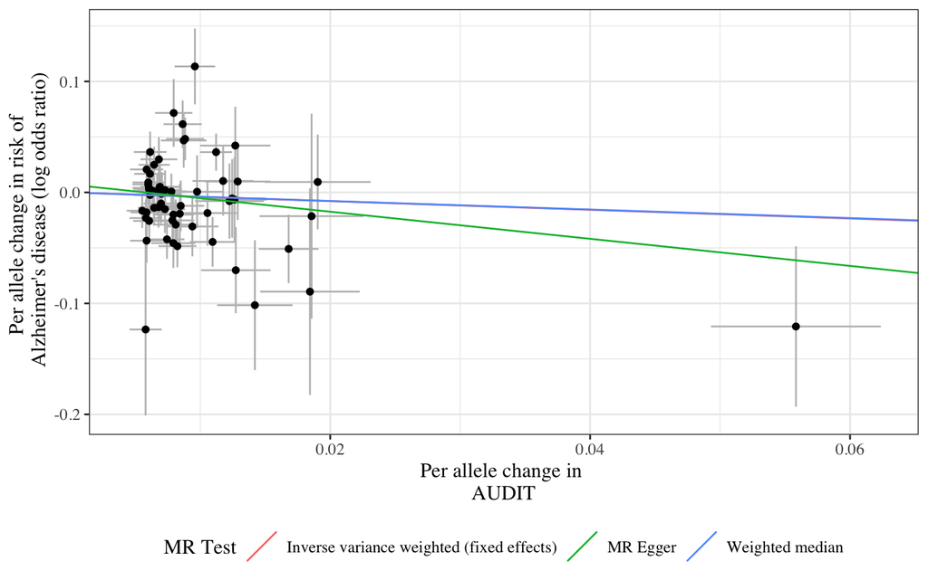

Fig. 1: Scatterplot of SNP effects for the association of Trait and LOAD

Figure 2 and Table 1 shows the SNP-specific effects and overall IVW, weighted median and Egger regression causal estimates of genetically predicted AUDIT on risk of LOAD.

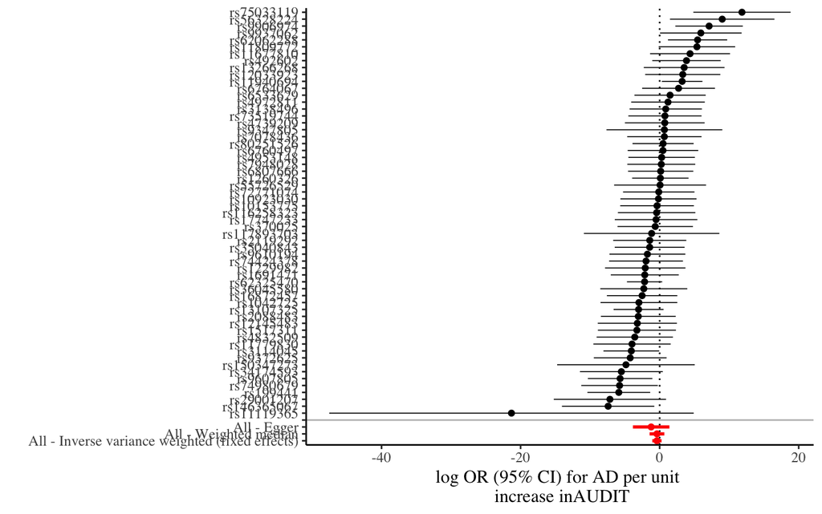

Fig. 2: Forrest plot of Wald ratios and 95% CIs for SNP-specific and overall IVW, Weighted median and Egger associations

**Table 1:** MR estimates for AUDIT and LOAD

|  | SNP | b | se | p |
| --- | --- | --- | --- | --- |
| 1 | rs10153775 | -0.3745501 | 2.7032749 | 0.8898024239 |
| 2 | rs1042725 | -2.9803298 | 2.8177664 | 0.2901957433 |
| 3 | rs10923030 | -0.1711206 | 2.7949691 | 0.9511804263 |
| 4 | rs11119365 | -21.3129465 | 13.3745211 | 0.1110372225 |
| 5 | rs116258323 | -0.4336653 | 2.8429168 | 0.8787591727 |
| 6 | rs11677810 | 4.3720016 | 2.9342293 | 0.1362242359 |
| 7 | rs11779830 | -3.9722800 | 2.8373429 | 0.1615133185 |
| 8 | rs117893703 | -1.1526446 | 4.9714532 | 0.8166524588 |
| 9 | rs11809772 | 5.3623604 | 2.8072186 | 0.0561069418 |
| 10 | rs11940694 | 3.2361594 | 1.4888116 | 0.0297312278 |

[output cut: 52 more lines]

Figure 3 shows a funnel plot to detect pleiotropy and Table 2 show the results of Cochrans Q heterogeneity test to assess for the presence of pleiotropy.

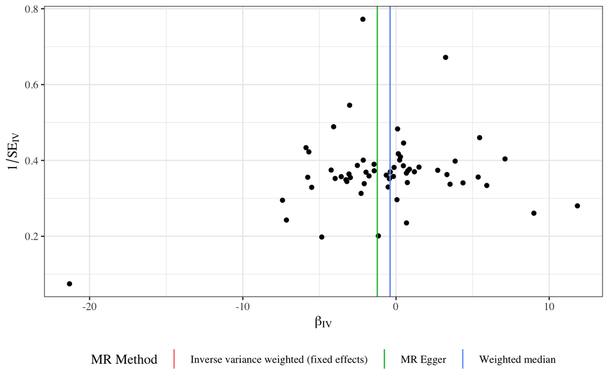

Fig. 3: Funnel plot of the Trait – LOAD causal estimates against their precession

**Table 2:** Heterogenity tests for AUDIT and LOAD

| exposure | outcome | method | Q | Q_df | Q_pval |
| --- | --- | --- | --- | --- | --- |
| audit | LOAD | MR Egger | 106.5801 | 57 | 7.591252e-05 |
| audit | LOAD | Inverse variance weighted | 107.3997 | 58 | 8.665471e-05 |

**Table 3:** Test for directional pleitropy for AUDIT and LOAD

| id.exposure | id.outcome | outcome | exposure | egger_intercept | se | pval |
| --- | --- | --- | --- | --- | --- | --- |
| CUc3qu | n4oDIX | LOAD | audit | 0.007139072 | 0.0107833 | 0.5106078 |

### AUDIT ~ AAOS

Figure 4 illustrates the SNP-specific associations with AUDIT versus the association between each SNP and AAOS.

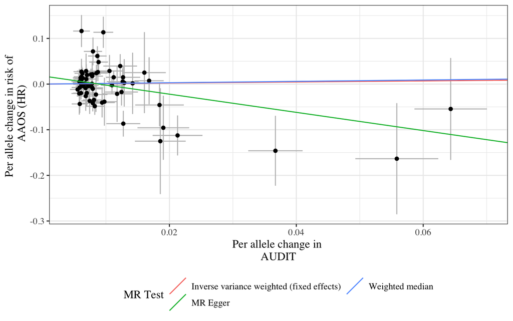

Fig. 4: Scatterplot of SNP effects for the association of Trait and AAOS

Figure 5 and Table 4 shows the SNP-specific effects and overall IVW, weighted median and Egger regression causal estimates of genetically predicted AUDIT on AAOS.

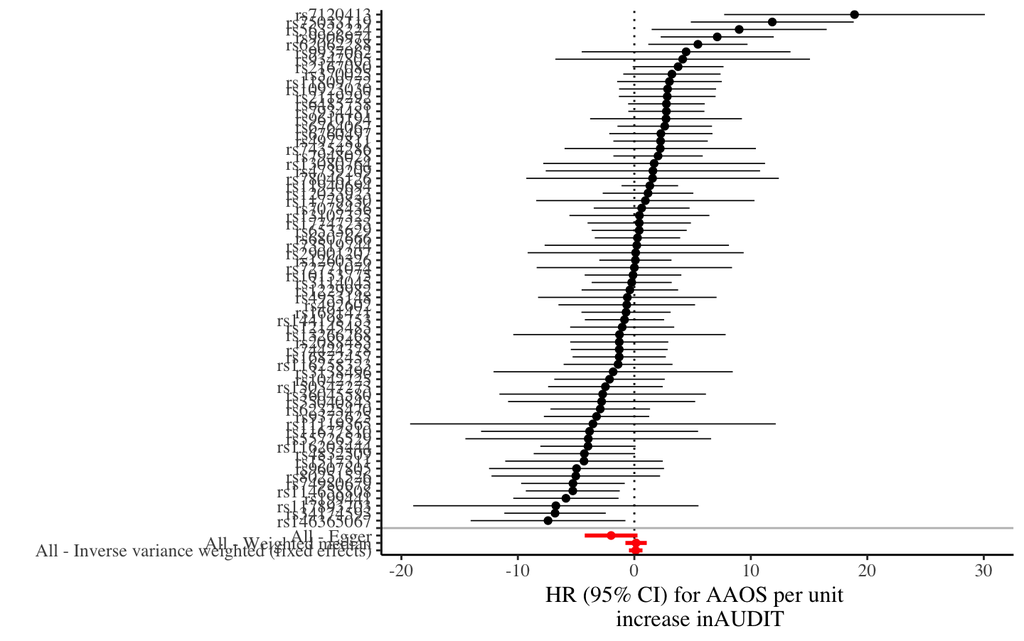

Fig. 5: Forrest plot of Wald ratios and 95% CIs for SNP-specific and overall IVW, Weighted median and Egger associations

**Table 4:** MR estimates for AUDIT and AAOS

|  | SNP | b | se | p |
| --- | --- | --- | --- | --- |
| 1 | rs10153775 | -0.11399352 | 2.1170225 | 0.9570577374 |
| 2 | rs1042725 | -2.13138739 | 2.4203891 | 0.3785359748 |
| 3 | rs10923030 | 2.85200924 | 2.1247469 | 0.1795046166 |
| 4 | rs11119365 | -3.55503400 | 8.0074552 | 0.6570675148 |
| 5 | rs114658808 | -5.28491568 | 2.0575938 | 0.0102141731 |
| 6 | rs116203444 | -3.98005884 | 2.0867386 | 0.0564803648 |
| 7 | rs116258323 | -1.39736588 | 2.3851590 | 0.5579705498 |
| 8 | rs11677810 | -3.84384032 | 4.7534514 | 0.4187211131 |
| 9 | rs11779830 | 0.94578096 | 4.7804928 | 0.8431688982 |
| 10 | rs117893703 | -6.73812345 | 6.2479802 | 0.2808337528 |

[output cut: 62 more lines]

Figure 6 shows a funnel plot to detect pleiotropy and Table 5 show the results of Cochrans Q heterogeneity test to assess for the presence of pleiotropy.

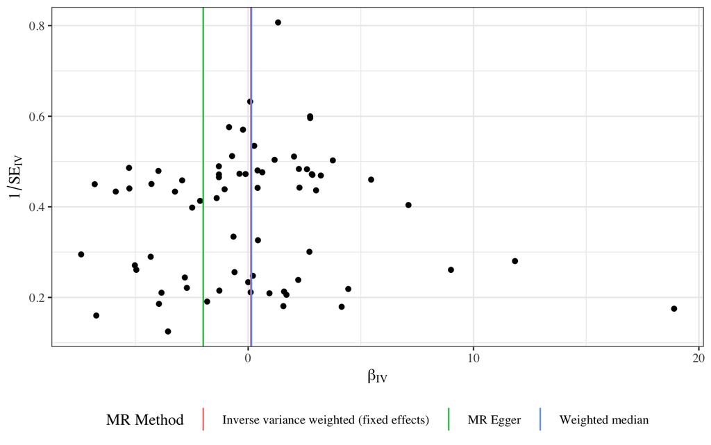

Fig. 6: Funnel plot of the traitohol Conumption – AAOS causal estimates against their precession

**Table 5:** Heterogenity tests for AUDIT and AAOS

| exposure | outcome | method | Q | Q_df | Q_pval |
| --- | --- | --- | --- | --- | --- |
| audit | AAOS | MR Egger | 117.6434 | 67 | 1.312476e-04 |
| audit | AAOS | Inverse variance weighted | 124.2725 | 68 | 3.719603e-05 |

**Table 6:** Test for directional pleitropy for AUDIT and AAOS

| id.exposure | id.outcome | outcome | exposure | egger_intercept | se | pval |
| --- | --- | --- | --- | --- | --- | --- |
| CUc3qu | twjWg1 | AAOS | audit | 0.01788705 | 0.009205698 | 0.05621451 |

### AUDIT ~ AB42

Figure 1 illustrates the SNP-specific associations with AUDIT versus the association between each SNP and AB42.

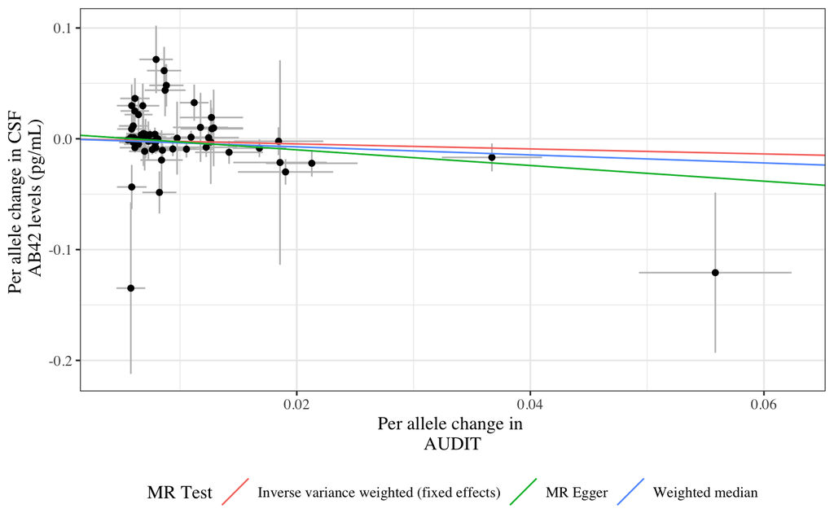

Fig. 1: Scatterplot of SNP effects for the association of trait and AB42

Figure 2 and Table 7 shows the SNP-specific effects and overall IVW, weighted median and Egger regression causal estimates of genetically predicted AUDIT CSF AB42 levels.

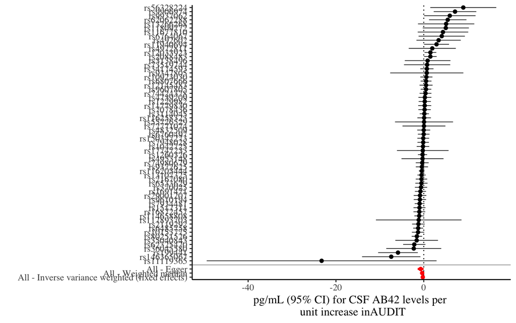

Fig. 2: Forrest plot of Wald ratios and 95% CIs for SNP-specific and overall IVW, Weighted median and Egger associations

**Table 7:** MR estimates for AUDIT and AB42

|  | SNP | b | se | p |
| --- | --- | --- | --- | --- |
| 1 | rs10153775 | -1.30522579 | 0.7179963 | 0.069083617 |
| 2 | rs1042725 | -0.18116793 | 0.7299099 | 0.803975110 |
| 3 | rs10923030 | 0.59549953 | 0.7018795 | 0.396195426 |
| 4 | rs11119365 | -23.26303800 | 13.3572637 | 0.081578099 |
| 5 | rs114658808 | -1.03725278 | 0.5646639 | 0.066218984 |
| 6 | rs116203444 | -0.45712106 | 0.3440667 | 0.183985670 |
| 7 | rs116258323 | 0.08191455 | 0.7867009 | 0.917070840 |
| 8 | rs11677810 | 4.37200158 | 2.9342293 | 0.136224236 |
| 9 | rs11779830 | 0.21426238 | 0.7592042 | 0.777775049 |
| 10 | rs117893703 | -1.15264462 | 4.9714532 | 0.816652459 |

[output cut: 56 more lines]

Figure 3 shows a funnel plot to detect pleiotropy and Table 8 show the results of Cochrans Q heterogeneity test to assess for the presence of pleiotropy.

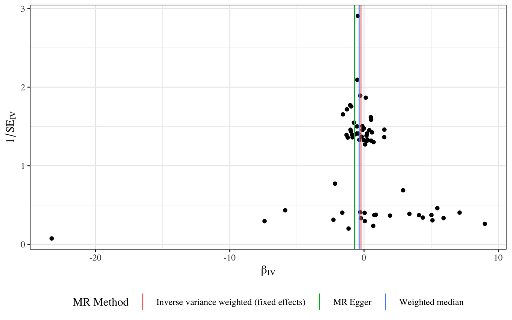

Fig. 3: Funnel plot of the trait – AB42 causal estimates against their precession

**Table 8:** Heterogenity tests for AUDIT and AB42

| exposure | outcome | method | Q | Q_df | Q_pval |
| --- | --- | --- | --- | --- | --- |
| audit | ab42 | MR Egger | 101.4598 | 61 | 0.0008817669 |
| audit | ab42 | Inverse variance weighted | 105.2684 | 62 | 0.0005023785 |

**Table 9:** Test for directional pleitropy for AUDIT and AB42

| id.exposure | id.outcome | outcome | exposure | egger_intercept | se | pval |
| --- | --- | --- | --- | --- | --- | --- |
| CUc3qu | Q3gyqB | ab42 | audit | 0.004310251 | 0.002848382 | 0.135386 |

### AUDIT ~ Ptau

Figure 1 illustrates the SNP-specific associations with AUDIT versus the association between each SNP and risk of Ptau.

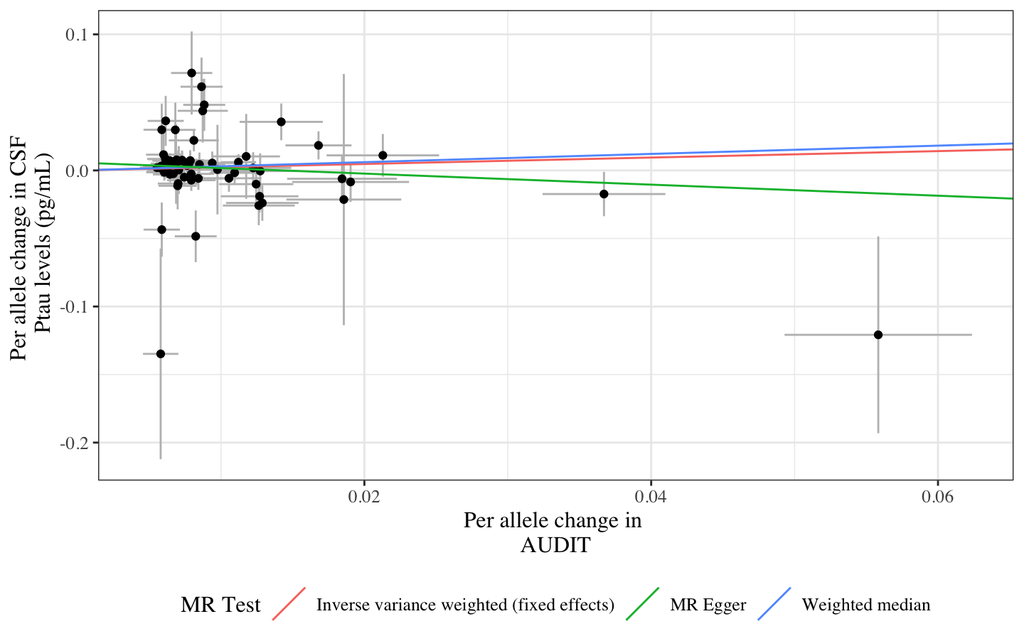

Fig. 1: Scatterplot of SNP effects for the association of trait and Ptau

Figure 2 and Table 9 shows the SNP-specific effects and overall IVW, weighted median and Egger regression causal estimates of genetically predicted AUDIT on risk of Ptau.

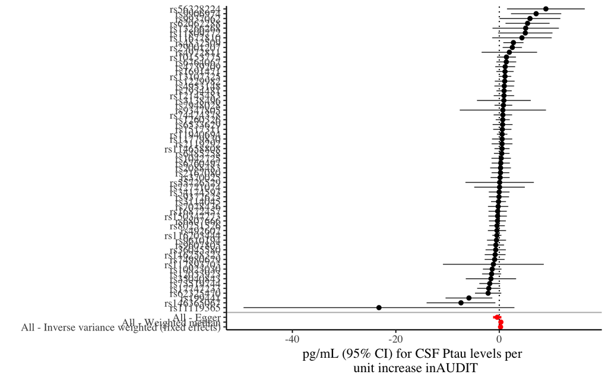

Fig. 2: Forrest plot of Wald ratios and 95% CIs for SNP-specific and overall IVW, Weighted median and Egger associations

**Table 9:** MR estimates for AUDIT and Ptau

|  | SNP | b | se | p |
| --- | --- | --- | --- | --- |
| 1 | rs10153775 | 1.37655316 | 0.9349097 | 0.140915168 |
| 2 | rs1042725 | 0.35926521 | 0.9576793 | 0.707555267 |
| 3 | rs10923030 | -1.37466845 | 0.9143542 | 0.132727920 |
| 4 | rs11119365 | -23.26303800 | 13.3572637 | 0.081578099 |
| 5 | rs114658808 | 0.52003570 | 0.7398882 | 0.482144782 |
| 6 | rs116203444 | -0.47264901 | 0.4437725 | 0.286843984 |
| 7 | rs116258323 | -0.80950851 | 1.0263412 | 0.430268430 |
| 8 | rs11677810 | 4.37200158 | 2.9342293 | 0.136224236 |
| 9 | rs11779830 | 0.54150259 | 0.9947896 | 0.586208347 |
| 10 | rs117893703 | -1.15264462 | 4.9714532 | 0.816652459 |

[output cut: 56 more lines]

Figure 3 shows a funnel plot to detect pleiotropy and Table 10 show the results of Cochrans Q heterogeneity test to assess for the presence of pleiotropy.

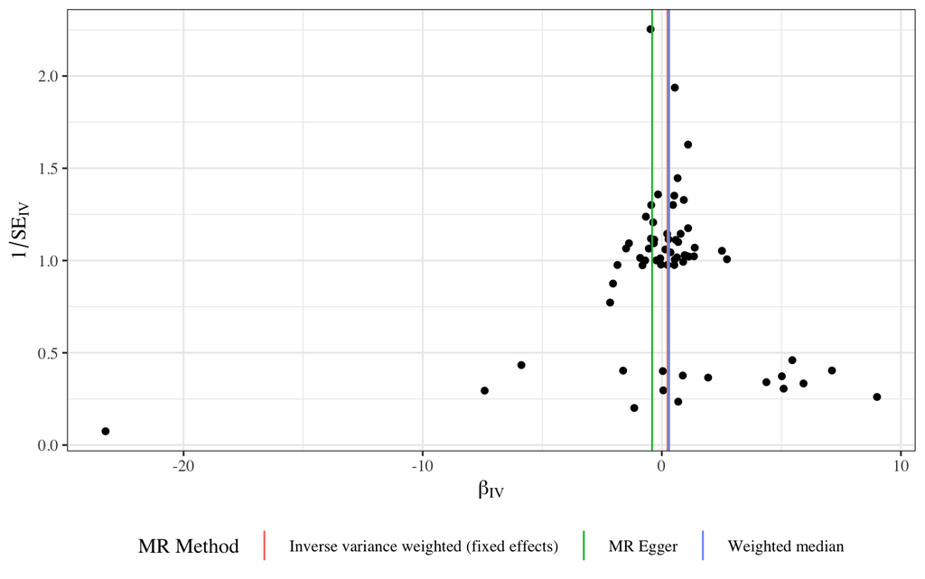

Fig. 3: Funnel plot of the trait – Ptau causal estimates against their precession

**Table 10:** Heterogenity tests for AUDIT and Ptau

| exposure | outcome | method | Q | Q_df | Q_pval |
| --- | --- | --- | --- | --- | --- |
| audit | ptau | MR Egger | 93.94017 | 61 | 0.004302383 |
| audit | ptau | Inverse variance weighted | 98.35642 | 62 | 0.002251941 |

**Table 11:** Test for directional pleitropy for AUDIT and Ptau

| id.exposure | id.outcome | outcome | exposure | egger_intercept | se | pval |
| --- | --- | --- | --- | --- | --- | --- |
| CUc3qu | BmYIVt | ptau | audit | 0.005805133 | 0.003428042 | 0.0954758 |

### AUDIT ~ Tau

Figure 1 illustrates the SNP-specific associations with AUDIT versus the association between each SNP and CSF Tau levels.

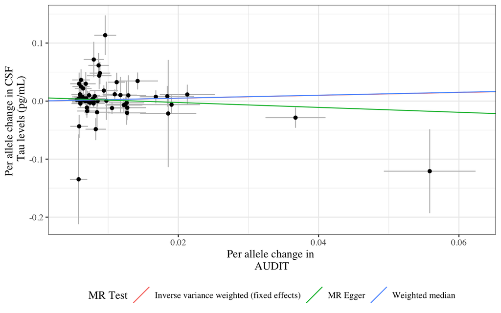

Fig. 1: Scatterplot of SNP effects for the association of trait and Tau

Figure 2 and Table 12 shows the SNP-specific effects and overall IVW, weighted median and Egger regression causal estimates of genetically predicted AUDIT on risk of Tau.

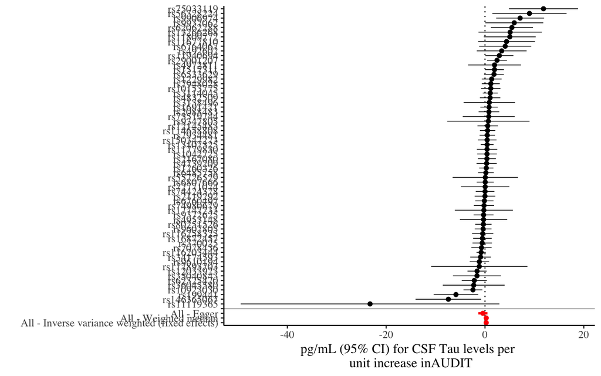

Fig. 2: Forrest plot of Wald ratios and 95% CIs for SNP-specific and overall IVW, Weighted median and Egger associations

**Table 12:** MR estimates for AUDIT and Tau

|  | SNP | b | se | p |
| --- | --- | --- | --- | --- |
| 1 | rs10153775 | 1.173481851 | 0.9980947 | 0.2397059933 |
| 2 | rs1042725 | 0.410021133 | 1.0183697 | 0.6872240828 |
| 3 | rs10923030 | -2.438467901 | 0.9751020 | 0.0123937204 |
| 4 | rs11119365 | -23.263038001 | 13.3572637 | 0.0815780994 |
| 5 | rs114658808 | 0.533659041 | 0.7953211 | 0.5022216584 |
| 6 | rs116203444 | -0.776669936 | 0.4786423 | 0.1046637647 |
| 7 | rs116258323 | -0.463620302 | 1.0970125 | 0.6725719552 |
| 8 | rs11677810 | 4.372001584 | 2.9342293 | 0.1362242359 |
| 9 | rs11779830 | 0.420786546 | 1.0532561 | 0.6895173065 |
| 10 | rs117893703 | -1.152644619 | 4.9714532 | 0.8166524588 |

[output cut: 57 more lines]

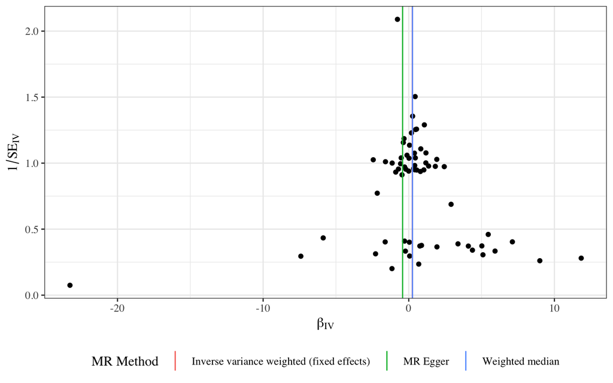

Fig. 3: Funnel plot of the trait – Tau causal estimates against their precession

**Table 14:** Heterogenity tests for AUDIT and Tau

| exposure | outcome | method | Q | Q_df | Q_pval |
| --- | --- | --- | --- | --- | --- |
| audit | tau | MR Egger | 102.4198 | 62 | 0.0009461371 |
| audit | tau | Inverse variance weighted | 106.3573 | 63 | 0.0005259888 |

**Table 15:** Test for directional pleitropy for AUDIT and Tau

| id.exposure | id.outcome | outcome | exposure | egger_intercept | se | pval |
| --- | --- | --- | --- | --- | --- | --- |
| CUc3qu | p9QwEt | tau | audit | 0.006023598 | 0.003901623 | 0.1277091 |

## MR analysis results

| exposure | outcome | method | nsnp | b | se | pval | Signif |
| --- | --- | --- | --- | --- | --- | --- | --- |
| audit | LOAD | IVW | 59 | -0.3915139 | 0.3405568 | 0.25029681 |  |
| audit | LOAD | Weighted median | 59 | -0.3853336 | 0.5553988 | 0.48780996 |  |
| audit | LOAD | MR Egger | 59 | -1.2226039 | 1.3389230 | 0.36502312 |  |
| audit | AAOS | IVW | 69 | 0.1173032 | 0.2962496 | 0.69213411 |  |
| audit | AAOS | Weighted median | 69 | 0.1493581 | 0.4663285 | 0.74875225 |  |
| audit | AAOS | MR Egger | 69 | -1.9947612 | 1.1557021 | 0.08895359 | . |
| audit | ab42 | IVW | 63 | -0.2277479 | 0.1022173 | 0.02587538 | * |
| audit | ab42 | Weighted median | 63 | -0.3632391 | 0.1566274 | 0.02038803 | * |
| audit | ab42 | MR Egger | 63 | -0.7091500 | 0.3443614 | 0.04373923 | * |
| audit | ptau | IVW | 63 | 0.2369665 | 0.1239576 | 0.05591799 | . |

[output cut: 5 more lines]